# trySignRestrictions

Vignette Author

2019-04-28

## Introduction

This vignette intends to go through the application of traditional sign restrictions methodology to the labour market data. This data set was used to illustrate the shortcomings of this approach to shock identification in the Structural Vector AutoRegressions (SVAR) in Baumeister and Hamilton (2015). The data comprises wage and employment growth in the US for the period from 1970Q1 until 2014Q2.

All the commands and data are stored in the package **trySignRestrictions**.

```r
library(Matrix)
library(mvnfast) # use rvn: generate multivariate normal variates
library(grid)
library(gridExtra)
suppressPackageStartupMessages(library(tidyverse))
suppressPackageStartupMessages(library(magrittr))
suppressPackageStartupMessages(library(tibbletime))
library(trySignRestrictions)

set.seed( 17 )
```

## Data

The labour market data set is pre-installed in the package and it can be called into R session as follows:

```r
# load data from the package
data(dataLabourMarket); dataLabourMarket
```

```
#> # A time tibble: 261 x 22
#> # Index: date
#>        w     n date       const   w_DLn  n_DLn w_DLn_L1 w_DLn_L2 w_DLn_L3
#>    <dbl> <dbl> <date>     <dbl>   <dbl>  <dbl>    <dbl>    <dbl>    <dbl>
#>  1  37.7 43739 1949-06-01     1  0.340  -1.13    1.58     1.88     0.340
#>  2  38.1 43784 1949-09-01     1  1.05    0.103   0.340    1.58     1.88
#>  3  38.0 43517 1949-12-01     1 -0.0841 -0.612   1.05     0.340    1.58
#>  4  39.1 43952 1950-03-01     1  2.87    0.995  -0.0841   1.05     0.340
#>  5  39.7 45084 1950-06-01     1  1.38    2.54    2.87    -0.0841   1.05
#>  6  39.7 46442 1950-09-01     1  0.118   2.97    1.38     2.87    -0.0841
#>  7  39.9 46855 1950-12-01     1  0.447   0.885   0.118    1.38     2.87
#>  8  39.3 47871 1951-03-01     1 -1.59    2.15    0.447    0.118    1.38
#>  9  39.8 48068 1951-06-01     1  1.22    0.411  -1.59     0.447    0.118
#> 10  40.2 47955 1951-09-01     1  1.17   -0.235   1.22    -1.59     0.447
#> # ... with 251 more rows, and 13 more variables: w_DLn_L4 <dbl>,
#> #   w_DLn_L5 <dbl>, w_DLn_L6 <dbl>, w_DLn_L7 <dbl>, w_DLn_L8 <dbl>,
#> #   n_DLn_L1 <dbl>, n_DLn_L2 <dbl>, n_DLn_L3 <dbl>, n_DLn_L4 <dbl>,
#> #   n_DLn_L5 <dbl>, n_DLn_L6 <dbl>, n_DLn_L7 <dbl>, n_DLn_L8 <dbl>
```

It contains wage and employment time series in levels as well as their transformations to quarterly growth rates and their lagged values up to the 8th order. The data set was downloaded from the original MATLAB file that can be found at the Baumeister webpage. Below we present the auxiliary code used for data download and transformation for the sake of the reference.

```r
if(FALSE){
### path to folder with the course materials
#path <- "D:/backup/LNB/CBAUMEISTER/BVARCOURSE2018/replication_codes/"
path <- "C:/BBB/CBAUMEISTER/BVARCOURSE2018/replication_codes/" #

    funcLags <- function( var, n = 1, fmt = "%s_L%02d"){
    ### from https://purrple.cat/blog/2018/03/02/multiple-lags-with-tidy-evaluation/
    ### n multiple lags of one variable var
      var <- enquo(var)

      indices <- seq_len(n)
      map( indices, ~quo(lag(!!var, !!.x)) ) %>%
          set_names( sprintf( fmt, rlang::quo_text( var ), indices ) )
    }

    dataLabourMarket = R.matlab::readMat( paste0( path, "application3/","labor_data.mat") )$data %>%
              data.frame %>%
              set_names( c( "w", "n") ) %>%
              mutate( date = seq( as.Date("1947-03-01"), length.out = n(), by = "3 months") ) %>%
              mutate( const = 1 ) %>%
              mutate_at( .vars = c( "w", "n"), .funs = funs( DLn = ( log( . ) - lag( log( . ), n = 1 ) ) * 100 ) ) %>%
              as_tbl_time( index = date ) %>%
              mutate( !!!funcLags( w_DLn, n = 8, fmt = "%s_L%1d" ) ) %>%
              mutate( !!!funcLags( n_DLn, n = 8, fmt = "%s_L%1d" ) ) %>% na.omit

}
```

## VAR(8): Estimation

Set the following optional arguments:

```r
opt                <- list()
opt$p              <- 8 # VAR(p)
opt$asy            <- c( "w_DLn", "n_DLn" )
opt$asx            <- paste0( opt$asy, "_L", rep( seq_len( opt$p ),each = length(opt$asy) ) )
opt$stepIRF        <- 0:16    ### set length of IRF
opt$numIRFunsigned <- 10    ### number of unsigned IRF proposals to generate
```

```r
### set sign restrictions
mSignRestriction <- c( 1, -1, 1, 1 ) %>% matrix( nrow = sqrt( length(.) ), byrow = FALSE )
mSignRestriction %>% set_rownames( opt$asy )
```

```
#>       [,1] [,2]
#> w_DLn    1    1
#> n_DLn   -1    1
```

Estimate the reduced form VAR(8) using sample 1970Q1—2014Q2.

```r
### set sample
dateBeg <- '1970-03-01'
dateEnd <- '2014-06-01'
db <- filter_time(dataLabourMarket, dateBeg ~ dateEnd)

### Estimate VAR(8) model
mY <- db %>% select(        opt$asy ) %>% as.matrix
mX <- db %>% select( const, opt$asx ) %>% as.matrix

### get RFVAR coefficients
varCoef <- solve( crossprod(mX), crossprod( mX, mY ) )

### covariance of residual matrix
mRes   <- mY - mX %*% varCoef
mSigma <- var( mRes )

### remove constant from the varCoef
varCoef %<>% t %>% .[, -which( colnames(mX) == "const" ) ]

### create companion matrix
mComp <- getCompanionForm( varCoef )
mComp %>% tbl_df
```

```
#> # A tibble: 16 x 16
#>    w_DLn_L1 n_DLn_L1 w_DLn_L2 n_DLn_L2 w_DLn_L3 n_DLn_L3 w_DLn_L4 n_DLn_L4
#>       <dbl>    <dbl>    <dbl>    <dbl>    <dbl>    <dbl>    <dbl>    <dbl>
#>  1  -0.113    0.0483  0.0906   -0.411    0.0572   0.457    0.0135  -0.0306
#>  2   0.0267   0.843   0.00211  -0.0640   0.0588   0.0822   0.0493  -0.178
#>  3   1        0       0         0        0        0        0        0
#>  4   0        1       0         0        0        0        0        0
#>  5   0        0       1         0        0        0        0        0
#>  6   0        0       0         1        0        0        0        0
#>  7   0        0       0         0        1        0        0        0
#>  8   0        0       0         0        0        1        0        0
#>  9   0        0       0         0        0        0        1        0
#> 10   0        0       0         0        0        0        0        1
#> 11   0        0       0         0        0        0        0        0
#> 12   0        0       0         0        0        0        0        0
#> 13   0        0       0         0        0        0        0        0
#> 14   0        0       0         0        0        0        0        0
#> 15   0        0       0         0        0        0        0        0
#> 16   0        0       0         0        0        0        0        0
#> # ... with 8 more variables: w_DLn_L5 <dbl>, n_DLn_L5 <dbl>,
#> #   w_DLn_L6 <dbl>, n_DLn_L6 <dbl>, w_DLn_L7 <dbl>, n_DLn_L7 <dbl>,
#> #   w_DLn_L8 <dbl>, n_DLn_L8 <dbl>
```

The companion matrix is used to generate IRFs at the specified horizon $h=0,...,h_{\max}$.

## IRFs without any sign restrictions

Before turning to the imposing sign restrictions on the IRFs it is instructive to take a look at the IRFs without sign restrictions imposed. That is we retain all IRF generated using the algorithm of Rubio-Ramirez, Waggoner and Zha (2010).

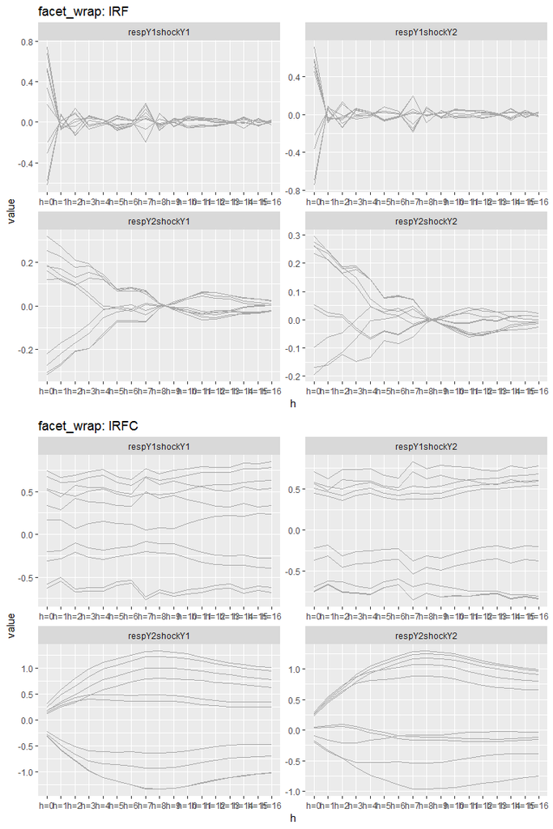

```r
### get opt$keepIRF draws of IRF and IRFC
listIRFunsigned <- vector( "list", opt$numIRFunsigned )
for( i in seq( opt$numIRFunsigned) ){

  listIRFunsigned[[ i ]] <- getIRFunsigned( mComp, mSigma, opt$stepIRF )

}

### cumulate unrestricted IRF
listIRFCunsigned <- listIRFunsigned %>% map( ~  apply( .x, 2, cumsum ) )

### convert either IRF or IRFC from list to data.frame
dfIRF  <- convertListToDataFrame( listIRFunsigned )
dfIRFC <- convertListToDataFrame( listIRFCunsigned )

### UNSIGNED IRF: prepare IRF(C) for plots
list2pltUnsigned <- list( IRF = dfIRF, IRFC = dfIRFC )

list2plt_IRF_IRFC_UNSIGNED <- names( list2pltUnsigned ) %>%
  map(  ~ list2pltUnsigned[[ .x ]] %>%
          gather( keyValue, value, starts_with("value") ) %>%
          ggplot( aes( x = h, y = value, group = keyValue) ) +
          geom_line( col = " darkgray"  ) +
          facet_wrap( ~ key, scales = "free" ) +
          ggtitle( paste( "facet_wrap:",.x ) ) )

do.call( grid.arrange, list2plt_IRF_IRFC_UNSIGNED  )
```

The distribution of impact at $h = 0$ is shown below. As discussed in Baumeister and Hamilton (2015) the density should and it indeed has a U-shape given that there are two modelled variables, i.e. n = 2.

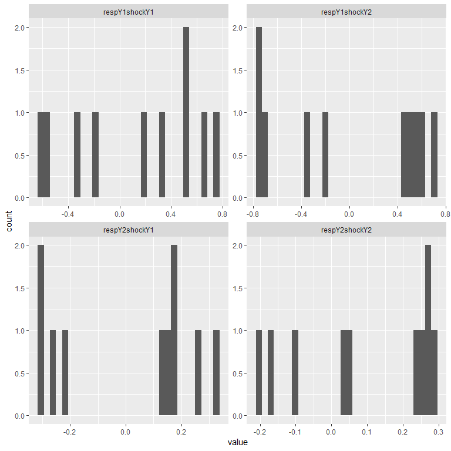

```r
dfIRF %>% filter( h == "h=0") %>%
  gather( keyValue, value, starts_with( "value" ) ) %>%
  ggplot( aes( x = value ) ) +
  geom_histogram() +
  facet_wrap( ~ key, scales = "free" )
```

## Impose sign restrictions

The Rubio-Ramirez, Waggoner and Zha (2010) algrithm uses the mapping between the residuals of reduced-form VAR $\varepsilon_t$ and structural shocks $v_t$ characterised by the multivariate standard normal distribution, $N(0_n, I_{n\times n})$

$$\varepsilon_t = H v_t.$$
The matrix $H$ represents the contamporaneous response of the modelled variables $y_t$ to structural shocks $v_t$ in the reduced-form VAR.

Rubio-Ramirez, Waggoner and Zha (2010) propose to use the QR algorithm for generating candidate draws of $H$ in the hope that at least some of those will comply with the sign restrictions in question. Their algorithm contains the following steps:

- Compute the Cholesky decomposition of the covariance matrix of reduced-form residuals $\Sigma$

$$\Sigma = PP'$$
- Generate a $n \times n$ matrix of independent N(0,1) random variables $X$

- Apply the QR decomposition to the matrix $X = QR$, where $Q$ is an orthogonal matrix and $R$ is upper triangular.
- Compute the candidate draw

$$H = PQ.$$

Observe that by construction

$$\Sigma = HH' = PQQ'P'$$
since the matrix $Q$ is orthogonal.

### One example of candidate $H$

For example,

```r
### number of variables
n <- 2

### covariance matrix of the reduced-form residuals
mSigma
```

```
#>            w_DLn      n_DLn
#> w_DLn 0.59538318 0.02509178
#> n_DLn 0.02509178 0.10193711
```

```r
### its Cholesky decomposition matrix P (lower triangular)
mP <- mSigma %>% chol %>% t; mP
```

```
#>           w_DLn     n_DLn
#> w_DLn 0.7716108 0.0000000
#> n_DLn 0.0325187 0.3176156
```

```r
### matrix of standard normal variates X
mX <- rmvn( n, rep(0,2), diag( n ) ); mX
```

```
#>            [,1]      [,2]
#> [1,]  0.9080014 2.0005046
#> [2,] -0.1690694 0.3029875
```

```r
### apply the QR decomposition
mQR <- qr( mX );

mQ <- qr.Q( mQR ); # cat('OLD: Q\n'); Q
mR <- qr.R( mQR ); # cat( 'R\n' ); R

### flip sign of columns where R[i,i] < 0: don't see why?
mQ <- diag( mR ) %>% sign %>% diag %>% `%*%`( mQ, . );# cat('NEW: Q\n'); Q

mH <- mP %*% mQ; cat('mH\n'); mH %>% round( digits = 3)
```

```
#> mH
#>         [,1]  [,2]
#> w_DLn  0.759 0.141
#> n_DLn -0.026 0.318
```

In this example a supply shock can be attributed to the *first* column as it raises wage ($h_{11} > 0$) and lowers employment ($h_{21} < 0$) whereas a demand shock can be attributed to the *second* column as it raises both wage ($h_{21} > 0$) and employment ($h_{22} > 0$).

### Another example of candidate $H$

Suppose that we get another candidate $H$ in the following form

```r
mH <- c( 0.2214489, -0.73915056, 0.3135868, 0.06000359 ) %>%
      matrix( nrow = 2, byrow = TRUE) %>%
      set_rownames( c("w_DLn", "n_DLn") )
mH
```

```
#>            [,1]        [,2]
#> w_DLn 0.2214489 -0.73915056
#> n_DLn 0.3135868  0.06000359
```

The question is how can we transform it to comply with the sign restrictions that we want to impose?

```r
mSignRestriction
```

```
#>      [,1] [,2]
#> [1,]    1    1
#> [2,]   -1    1
```

That’s it,

1. the supply and demand shocks should be ordered to the first and the second columns respectively;
2. the sign of the matrix elements in the first row should be positive.

First, we check whether we can recover the covariance matrix $\Sigma$ from that candidate draw?:

```r
mH %*% t( mH ) %>% round( digits = 6 )
```

```
#>          w_DLn    n_DLn
#> w_DLn 0.595383 0.025092
#> n_DLn 0.025092 0.101937
```

```r
mSigma %>% round( digits = 6)
```

```
#>          w_DLn    n_DLn
#> w_DLn 0.595383 0.025092
#> n_DLn 0.025092 0.101937
```

```r
identical( mH %*% t( mH ) %>% round( digits = 6 ), mSigma %>% round( digits = 6) )
```

```
#> [1] TRUE
```

Ordering of the shocks to the representation we desire can be achieved by two matrix manipulations:

- column swapping
- column sign flipping

To see how it is done:

```r
### impose positive entries in the first row
mH <- sign( mH[ 1, ] ) %>% diag %>% `%*%`( mH, . );
mH
```

```
#>            [,1]        [,2]
#> w_DLn 0.2214489  0.73915056
#> n_DLn 0.3135868 -0.06000359
```

```r
### swap columns by means of a permutation matrix
pm <- as( as.integer( c( 2, 1 ) ), "pMatrix" ) # library(Matrix)
mH <- mH %*% pm
mH
```

```
#>              [,1]      [,2]
#> w_DLn  0.73915056 0.2214489
#> n_DLn -0.06000359 0.3135868
```

The resulting matrix $H$ has the required ordering and normalisation of the shocks. The $\Sigma$ matrix can be recovered as well:

```r
mH %*% t( mH ) %>% round( digits = 6 )
```

```
#>          w_DLn    n_DLn
#> w_DLn 0.595383 0.025092
#> n_DLn 0.025092 0.101937
```

```r
mSigma %>% round( digits = 6)
```

```
#>          w_DLn    n_DLn
#> w_DLn 0.595383 0.025092
#> n_DLn 0.025092 0.101937
```

```r
identical( mH %*% t( mH ) %>% round( digits = 6 ), mSigma %>% round( digits = 6) )
```

```
#> [1] TRUE
```